# Clinical malaria trends

2002-2016

2017-02-15

Quique Bassat, Joe Brew, Bea Galatas

Collaborators list is non-exhaustive and alphabetical.

# Analysis

## OPD

### OPD: Absolute number of malaria cases over time

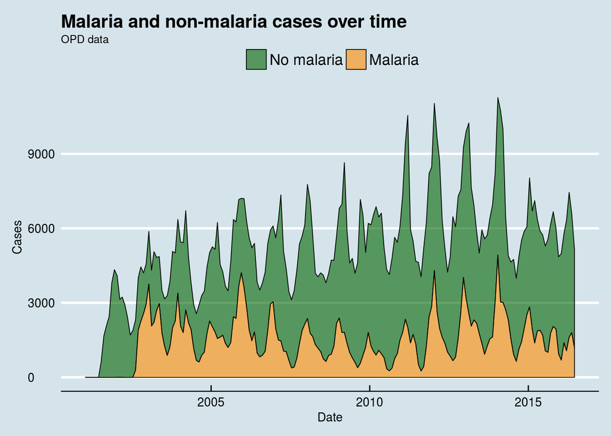

Clearly in the above chart, seasonality is driven by malaria. That said, even among non-malaria cases, there still appear to be seasonal trends.

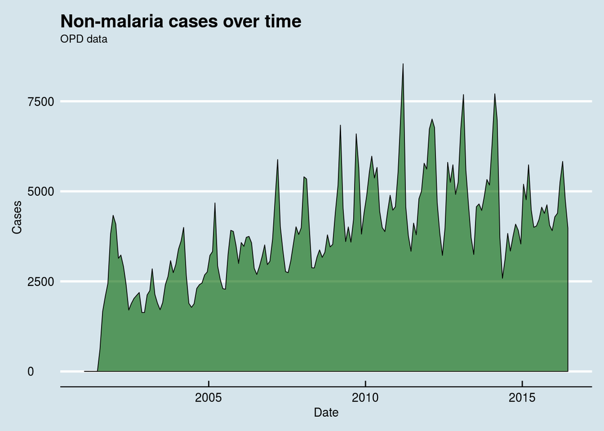

We can explore seasonality further by looking at each year.

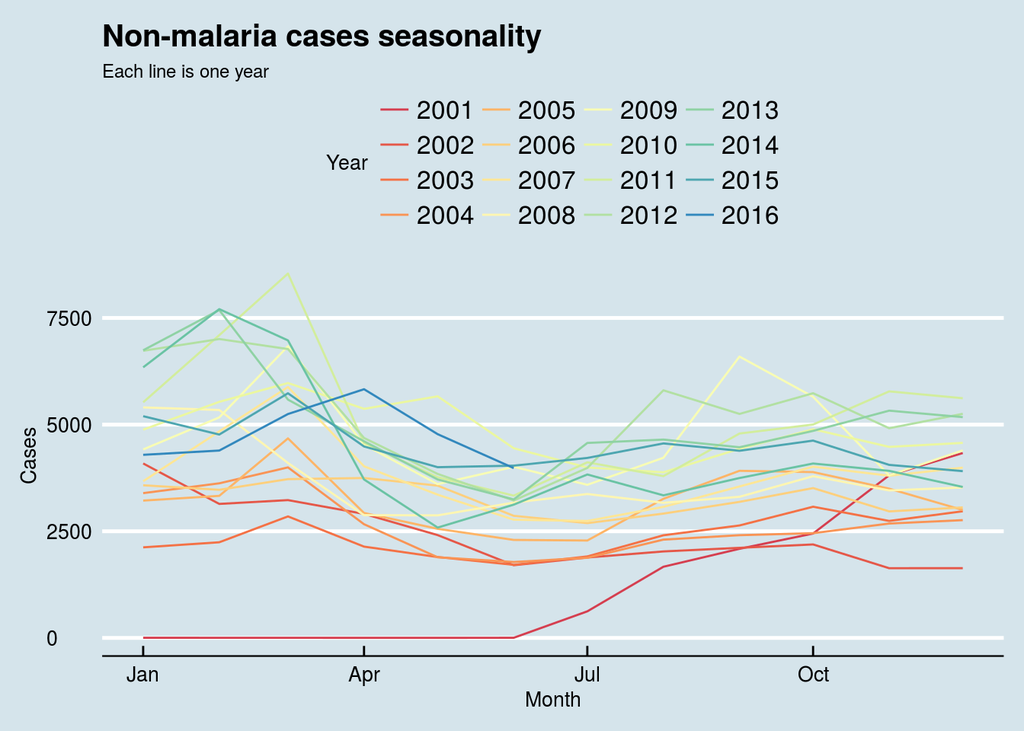

Malaria as a percentage of all cases is displayed in the below chart.

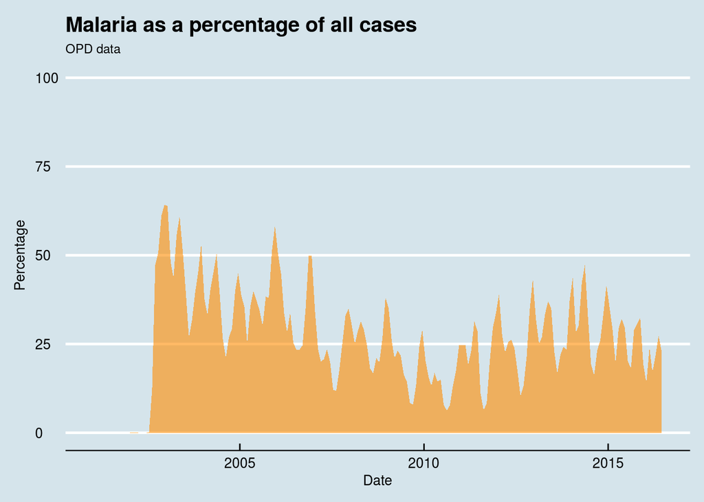

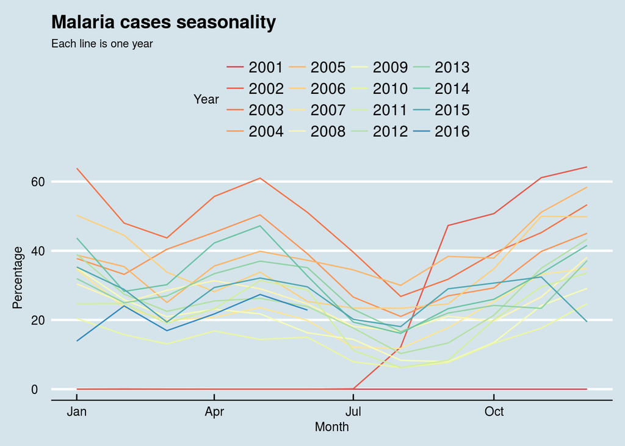

The above charts aggregated data at the monthly level. An alternative is to examine at the daily level.

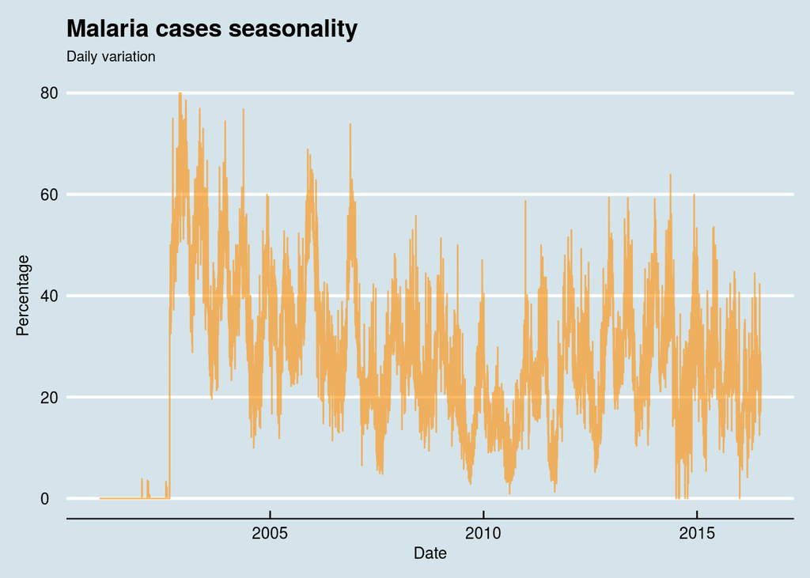

Seasonality using daily data is best examined through faceting. The below chart shows malaria (as a percentage of all OPD cases) for each year separately.

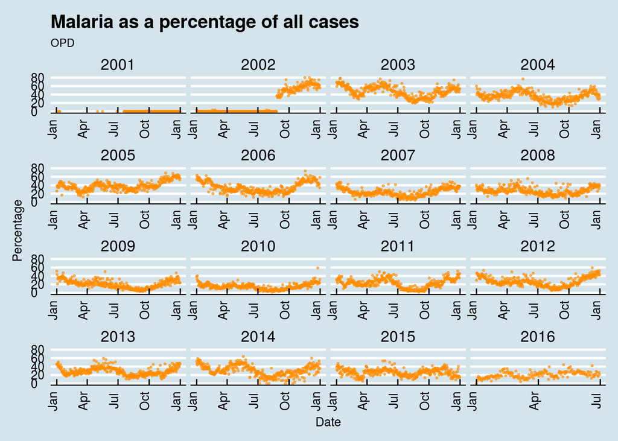

To see trends from a more birds-eye view, we can also aggregate at the year level. Doing so results in the following.

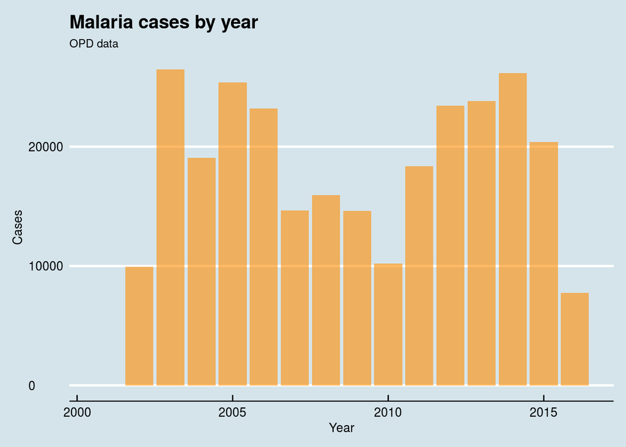

Instead of raw numbers (above), we can also examine yearly malaria in relative terms (below):

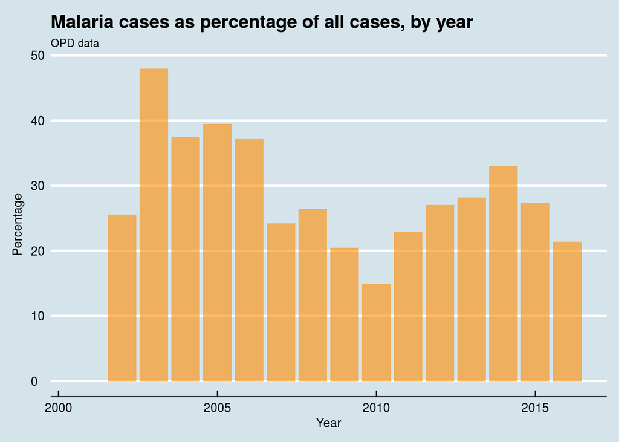

#### By age group

The distribution of all OPD visits is below.

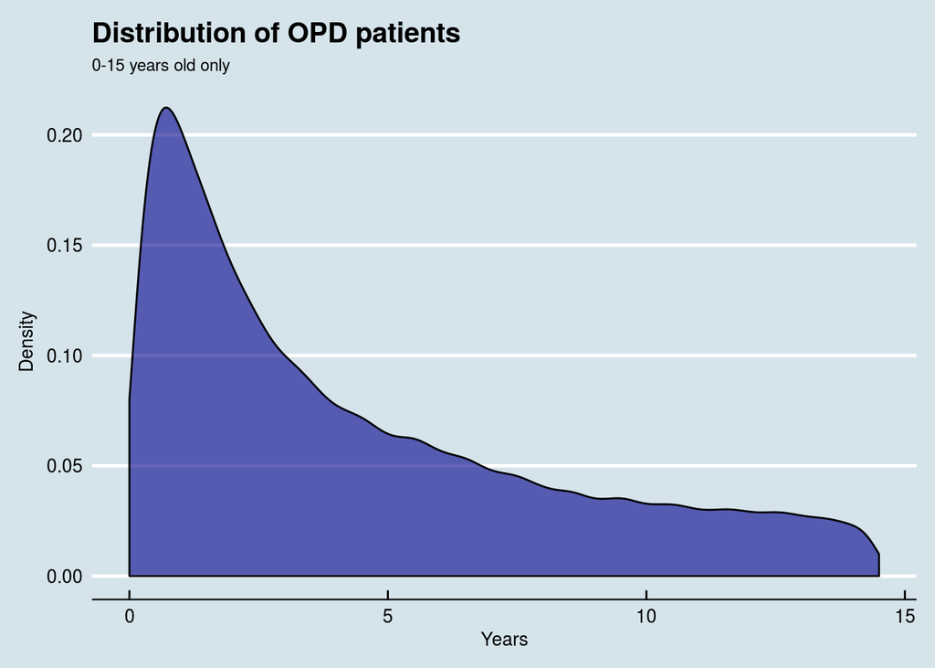

For our analysis, we divide into 5 groups, with distributions as follows:

[figure not shown]

The total daily OPD caseload for each group is seen below. Each point is one day’s caseload. The blue line is the smoothed trend.

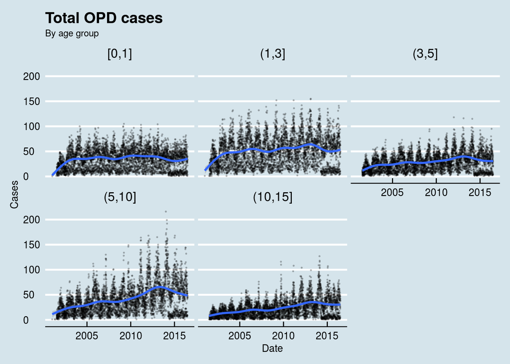

The below chart is identical to the above, but with malaria cases only.

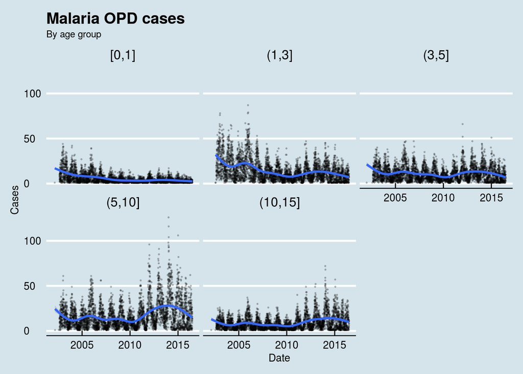

As an alternative to the above, we can examine each age group’s malaria cases as a proportion of the total number of visists from patients of that age group.

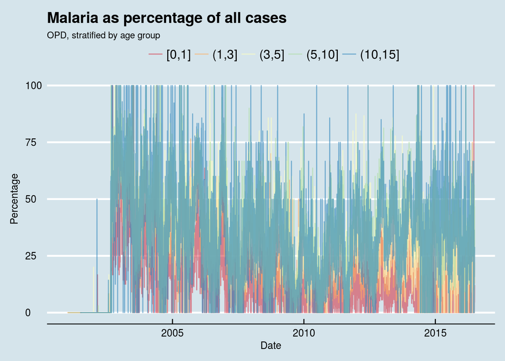

Since the above is to dense for clear understanding, we can facet for each year for a more in-depth exploration. The below chart shows one facet for each year, along with smoothed loess trend lines.

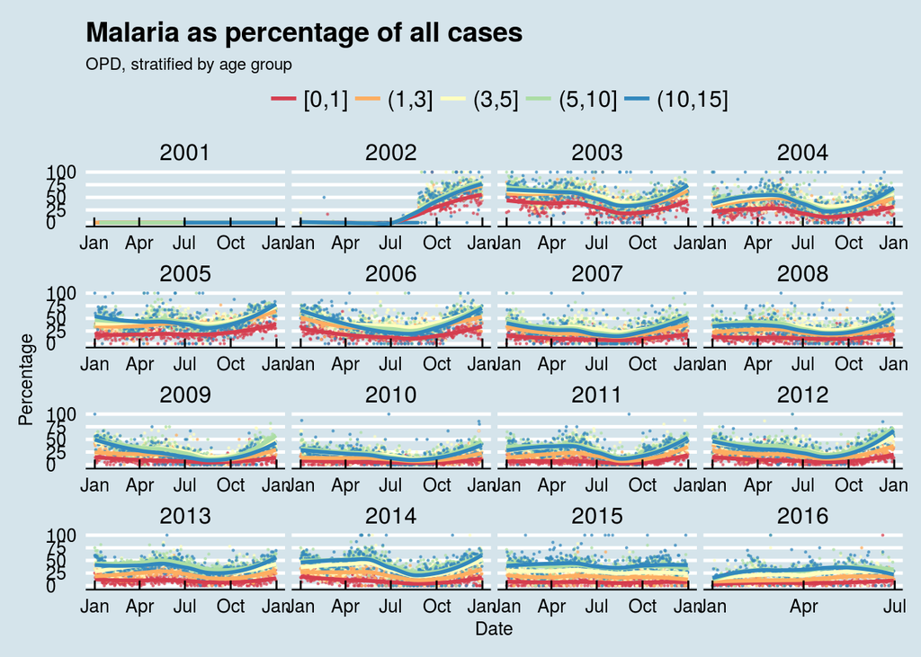

It appears that seasonal risk is similar across age groups.

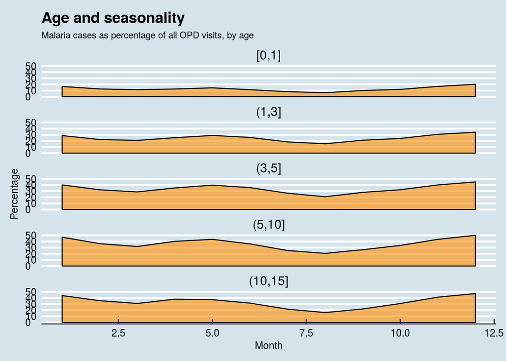

### Incidence: Malaria cases over time (relative to population at risk)

### Clinical profile of malaria

*What does non-complicated malaria look like over time?*

- Parasite densitites

  We still need servolab stuff
- Body temperature
- Hemoglobin
- Age distributions over time

#### Age group analysis

Cohort analysis with time-standardized x axis and cohort colored lines

(Everything up to here is for Katarina’s paper)

### Hotspot identifical / Spatial scan statistic

Bayesian spatial-temporal analysis

Validate using actual locations.

Compare clinical hotspots from OPD with community hotspots from xmal.

## INPD trends

### Absolute cases over time

### Cases as percentage of all INPD cases over time

### Case fatality rate

Use census as denominator

#### Over time

#### By geography

#### Spatio-temporal

### Risk factors for death

Matched case-control (or multinomial logistic regression) between:

1. In the field (asymptomatic, in the field, from xmal)
2. In the OPD (symptomatic, but quick to recover)
3. In the INPD (symptomatic, severe malaria)